# class08_markdown

## R Markdown

Creating some example data to work with

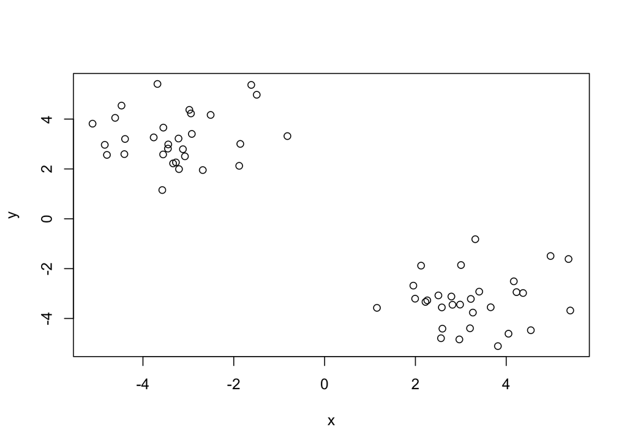

```r
tmp <- c(rnorm(30,-3), rnorm(30,3))
x <- cbind(x=tmp, y=rev(tmp))

plot(x)
```

Use the kmeans() function setting k to 2 and nstart=20 Inspect/print the results Q. How many points are in each cluster? Q. What ‘component’ of your result object details - cluster size? - cluster assignment/membership? - cluster center? Plot x colored by the kmeans cluster assignment and add cluster centers as blue points

```r
km<-kmeans(x, centers=2, nstart = 20)
```

picking up specific values from kmeans

```r
km$size
```

```
## [1] 30 30
```

```r
km$cluster
```

```
##  [1] 2 2 2 2 2 2 2 2 2 2 2 2 2 2 2 2 2 2 2 2 2 2 2 2 2 2 2 2 2 2 1 1 1 1 1
## [36] 1 1 1 1 1 1 1 1 1 1 1 1 1 1 1 1 1 1 1 1 1 1 1 1 1
```

Cluster vector can be used to assign which color goes to which data, set when plotting second line plots centers of kmeans

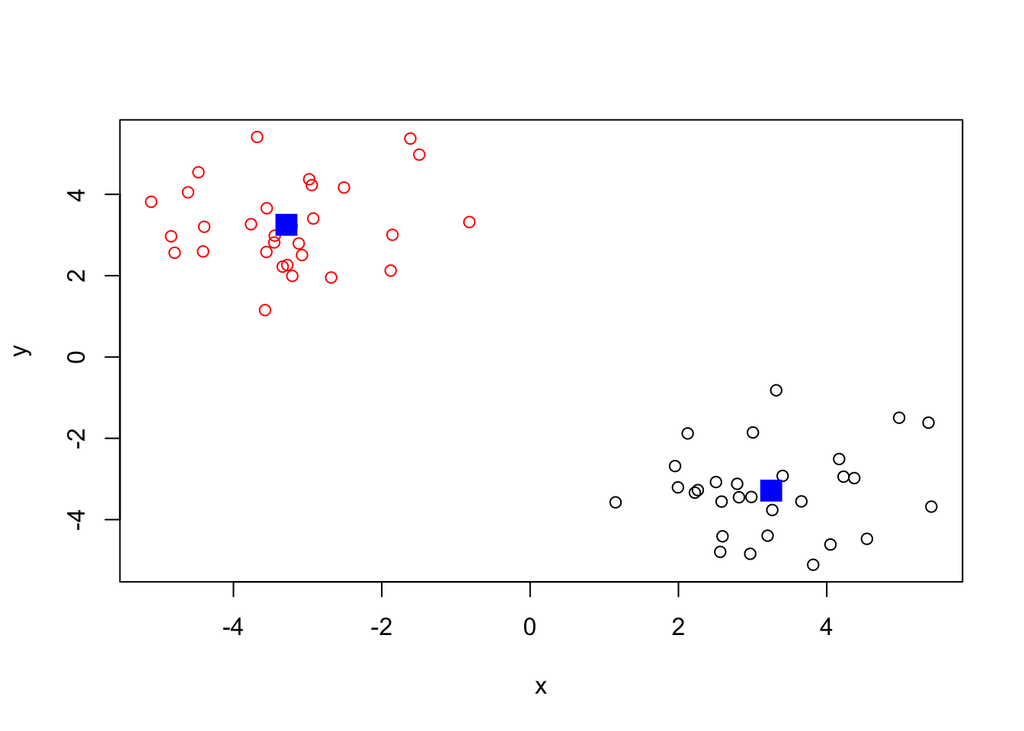

```r
plot(x, col=km$cluster)
points(km$centers, col="blue", pch=15, cex=2)
```

Hierarchical Clustering

First we need to calculate point (dis)similarity as the Euclidean distance between observations makes a 60x60 grid on how far each point is from another

```r
dist_matrix <- dist(x)
## view()
```

The hclust() function returns a hierarchical clustering model

```r
hc <- hclust(d = dist_matrix)
hc
```

```
##
## Call:
## hclust(d = dist_matrix)
##
## Cluster method   : complete
## Distance         : euclidean
## Number of objects: 60
```

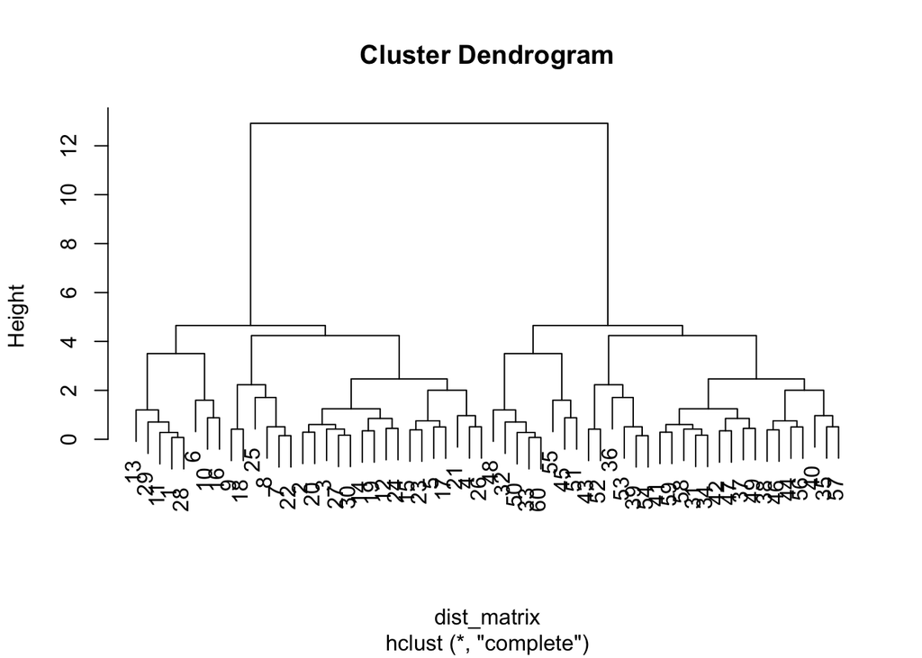

```r
#plotting hc will show you how the numbers are related
#tree shape shows hierarchical models, higher distance --> values further apart
plot(hc)
```

Can use cutree(hc, h=6) will cut tree at height 6

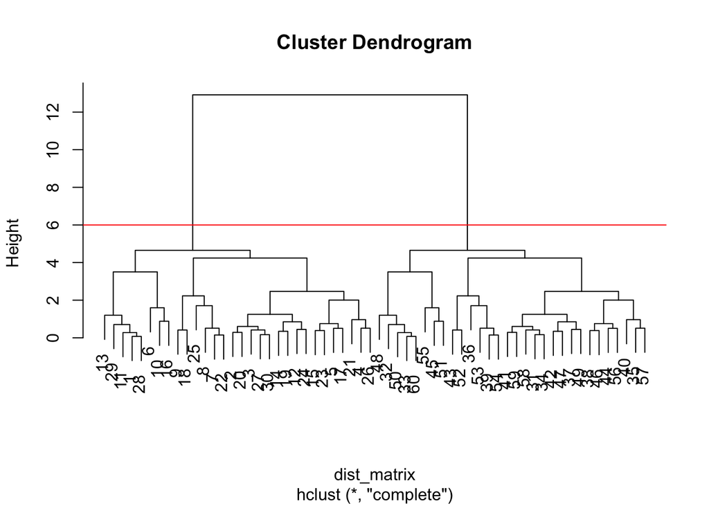

```r
plot(hc)
abline(h=6, col="red")
```

```r
cutree(hc, h=6)
```

```
##  [1] 1 1 1 1 1 1 1 1 1 1 1 1 1 1 1 1 1 1 1 1 1 1 1 1 1 1 1 1 1 1 2 2 2 2 2
## [36] 2 2 2 2 2 2 2 2 2 2 2 2 2 2 2 2 2 2 2 2 2 2 2 2 2
```

```r
# if use k= instead of h, will cut to have that many groups
```

Other Hierarchical CLustering

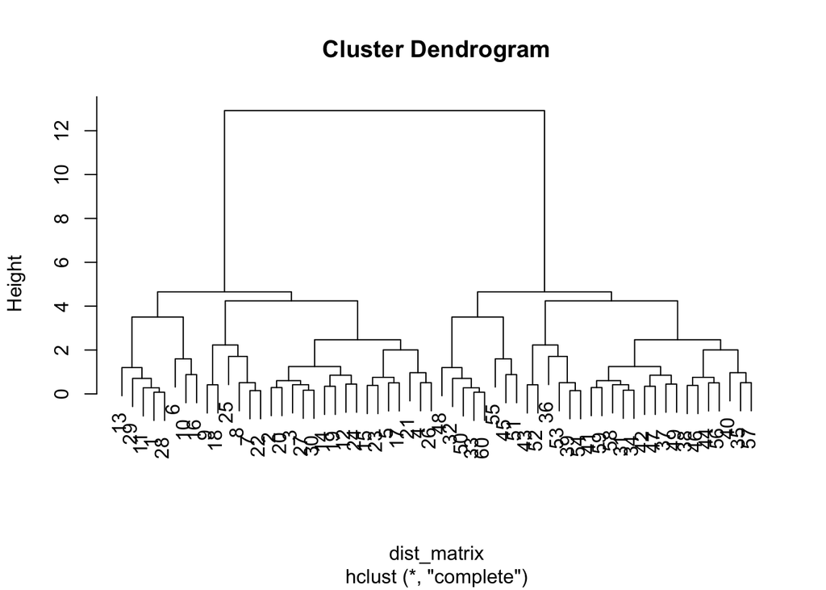

```r
# use dist_matrix

hc.complete <- hclust(dist_matrix, method = "average")
hc.complete <- hclust(dist_matrix, method = "single")
hc.complete <- hclust(dist_matrix, method = "complete")

plot(hc.complete)
```

Run hclust on groups to see overlapping

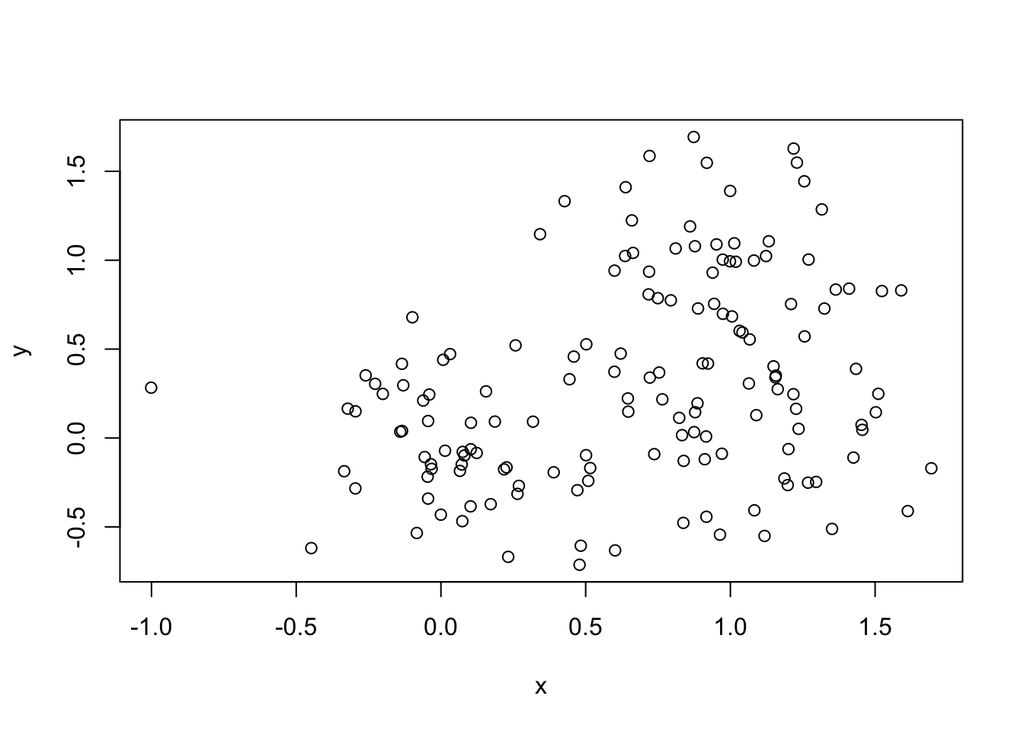

```r
# Step 1. Generate some example data for clustering
x <- rbind(
 matrix(rnorm(100, mean=0, sd = 0.3), ncol = 2), # c1
 matrix(rnorm(100, mean = 1, sd = 0.3), ncol = 2), # c2
 matrix(c(rnorm(50, mean = 1, sd = 0.3), # c3
 rnorm(50, mean = 0, sd = 0.3)), ncol = 2))
colnames(x) <- c("x", "y")
# Step 2. Plot the data without clustering
plot(x)
```

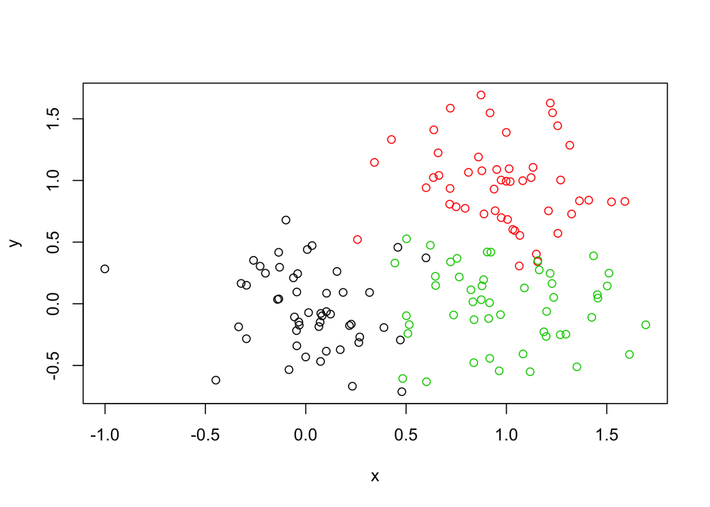

```r
# Step 3. Generate colors for known clusters
# (just so we can compare to hclust results)
col <- as.factor( rep(c("c1","c2","c3"), each=50) )
plot(x, col=col)
```

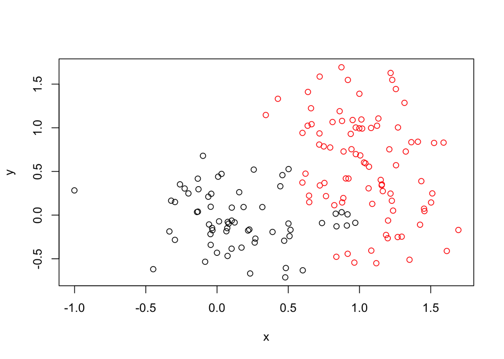

```r
# clustering code
example_dist <- dist(x)
example_clust <- hclust(example_dist)
example_clust2 <- cutree(example_clust, k=2)
plot(x, col=example_clust2)
```

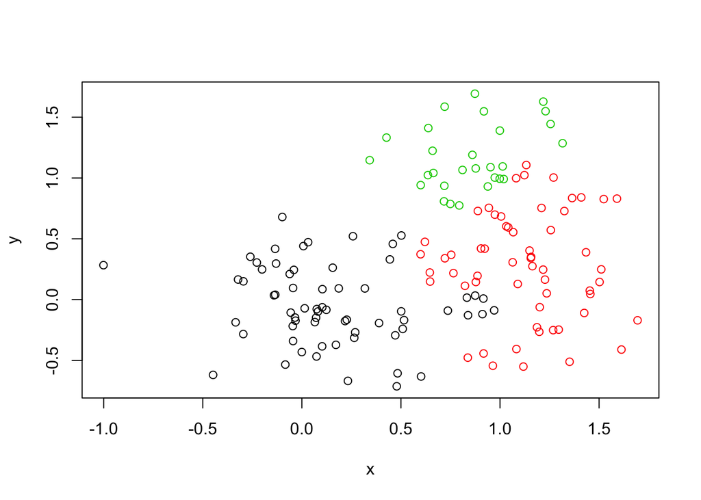

```r
example_clust3 <- cutree(example_clust, k=3)
plot(x, col=example_clust3)
```

PCA (Pricipal Component Analysis) Time

```r
## You can also download this file from the class website!
mydata <- read.csv("https://tinyurl.com/expression-CSV",
 row.names=1)
head(mydata)
```

```
##        wt1 wt2  wt3  wt4 wt5 ko1 ko2 ko3 ko4 ko5
## gene1  439 458  408  429 420  90  88  86  90  93
## gene2  219 200  204  210 187 427 423 434 433 426
## gene3 1006 989 1030 1017 973 252 237 238 226 210
## gene4  783 792  829  856 760 849 856 835 885 894
## gene5  181 249  204  244 225 277 305 272 270 279
## gene6  460 502  491  491 493 612 594 577 618 638
```

```r
## use t() fucntion can transpose (invert axis)
##    head(t(mydata))
```

Do a PCA analysis

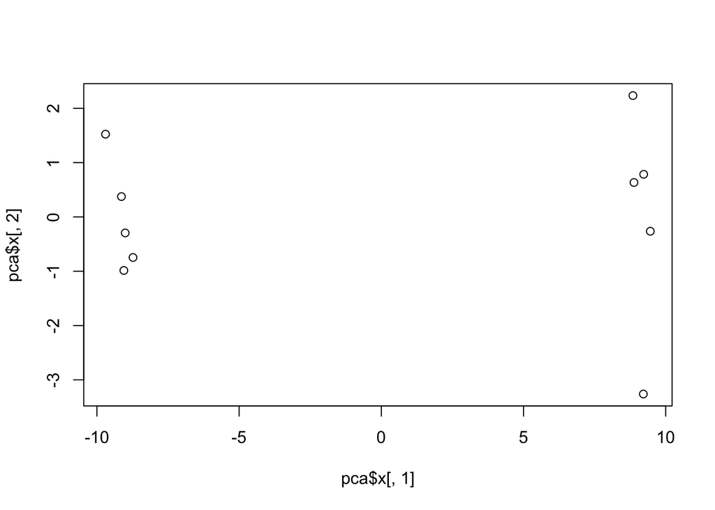

```r
pca <- prcomp(t(mydata), scale=TRUE)
## plot PCA1 vs PCA2
plot(pca$x[,1], pca$x[,2])
```

```r
## variance is squared of stdev
pca.var <- pca$sdev^2
pca.var.per <- round(pca.var/sum(pca.var)*100, 1)
pca.var.per
```

```
##  [1] 92.6  2.3  1.1  1.1  0.8  0.7  0.6  0.4  0.4  0.0
```

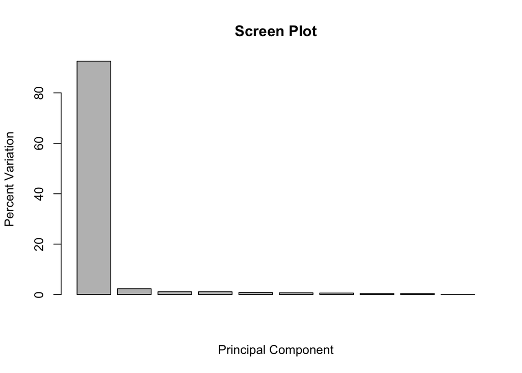

```r
## shows how much variance due to different levels of PC (PC1 vs PC2 vs PC3 etc)
barplot(pca.var.per, main="Screen Plot",
 xlab="Principal Component", ylab="Percent Variation")
```

```r
## results show PC1 is where most of variance located
```

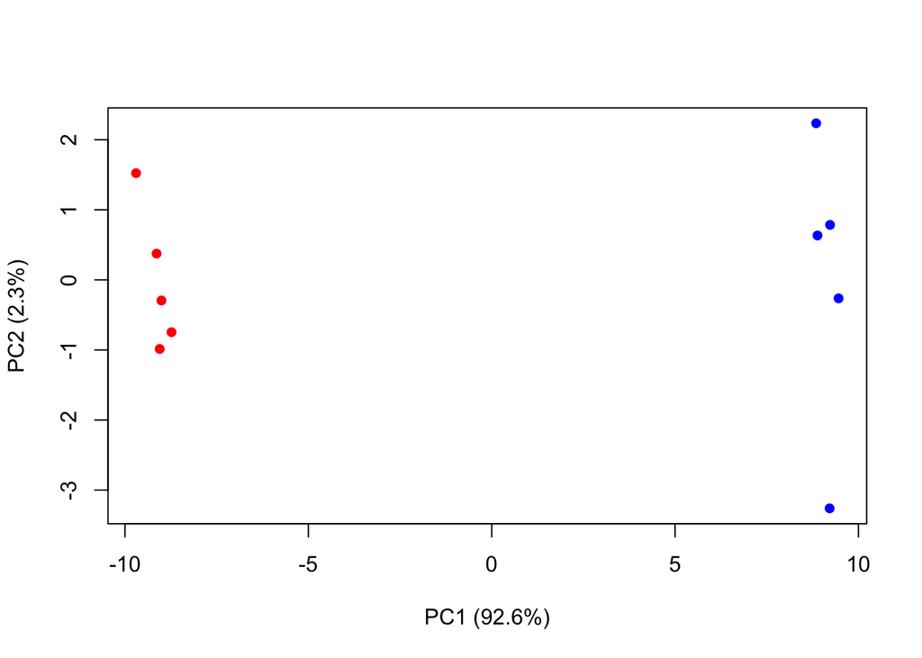

```
## integer(0)
```

```r
## A vector of colors for wt and ko samples
colvec <- colnames(mydata)
colvec[grep("wt", colvec)] <- "red"
colvec[grep("ko", colvec)] <- "blue"
plot(pca$x[,1], pca$x[,2], col=colvec, pch=16,
 xlab=paste0("PC1 (", pca.var.per[1], "%)"),
 ylab=paste0("PC2 (", pca.var.per[2], "%)"))
##click to identify function (interactive, use ESC to exit)
identify(pca$x[,1], pca$x[,2], labels=colnames(mydata))
```

PCA Hands On

```r
##read data
x <- read.csv("data/UK_foods.csv")
## use dim() or ncol() or nrow()
## View(x) beause cannot use when marking down
dim(x)
```

```
## [1] 17  5
```

need to take first row away from index because does not belong

```r
rownames(x) <- x[,1]
x <- x[,-1]
head(x)
```

```
##                England Wales Scotland N.Ireland
## Cheese             105   103      103        66
## Carcass_meat       245   227      242       267
## Other_meat         685   803      750       586
## Fish               147   160      122        93
## Fats_and_oils      193   235      184       209
## Sugars             156   175      147       139
```

Instead of doing this, can rather run single function upon reading file

```r
x <- read.csv("data/UK_foods.csv", row.names=1)
```

See if can find info on data based on barplots and other plots

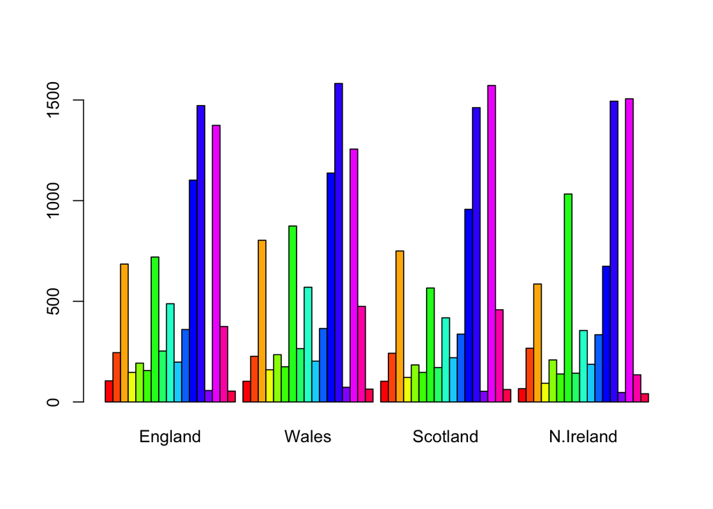

```r
barplot(as.matrix(x), beside=T, col=rainbow(nrow(x)))
```

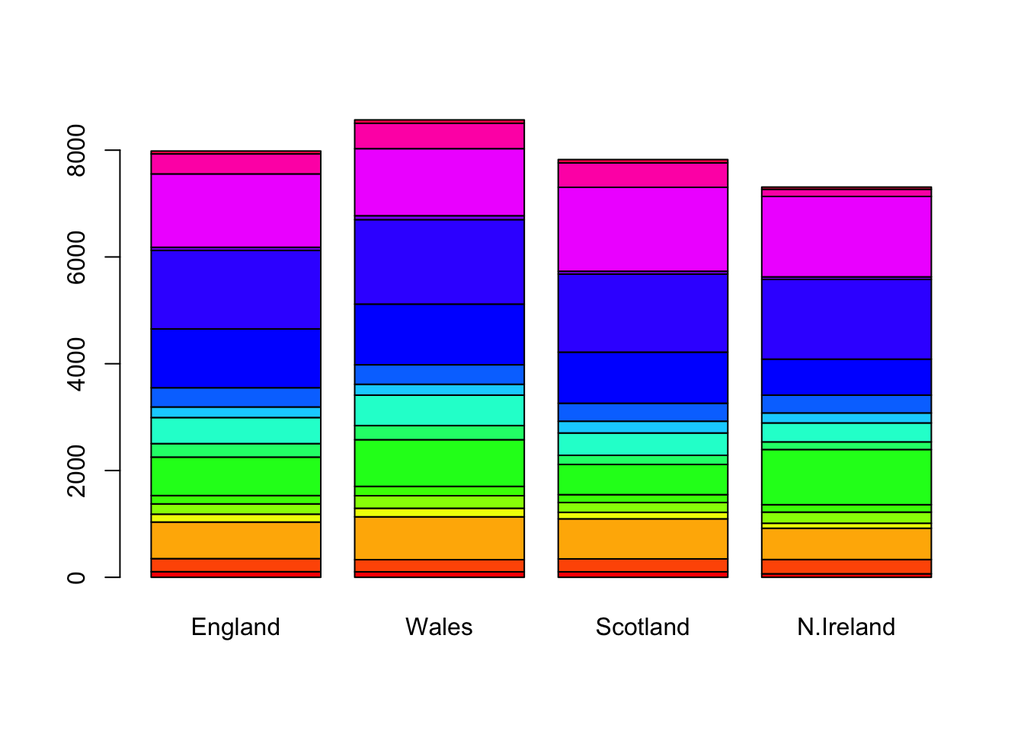

```r
barplot(as.matrix(x), beside=F, col=rainbow(nrow(x)))
```

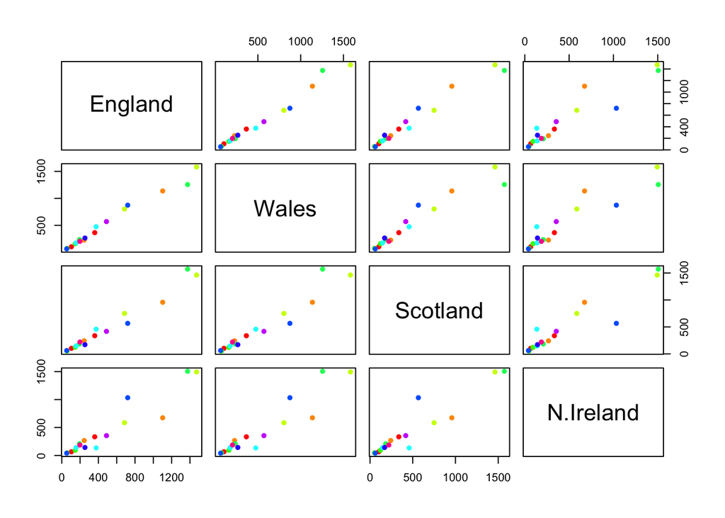

```r
pairs(x, col=rainbow(10), pch=16)
```

Hard to get info from data, instead use PCA

```r
## need to transpose because prcomp expects oberservations = rows and variables = columns
pca <- prcomp( t(x) )
summary(pca)
```

```
## Importance of components:
##                             PC1      PC2      PC3       PC4
## Standard deviation     324.1502 212.7478 73.87622 4.189e-14
## Proportion of Variance   0.6744   0.2905  0.03503 0.000e+00
## Cumulative Proportion    0.6744   0.9650  1.00000 1.000e+00
```

Trying to plto PC1 vs PC2

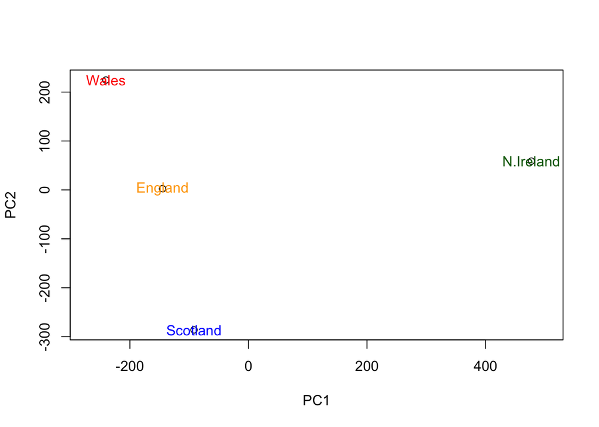

```r
plot(pca$x[,1], pca$x[,2], xlab="PC1", ylab="PC2", xlim=c(-270,500))
## second line just replacs the points with text
text(pca$x[,1], pca$x[,2], colnames(x), col=c("Orange", "Red", "Blue", "DarkGreen"))
```

Start to get stdev to understand how much variation in original data each PC accounts for

```r
v <- round( pca$sdev^2/sum(pca$sdev^2) * 100 )
v
```

```
## [1] 67 29  4  0
```